# REGRESION LOGISTICA

Lluis Albareda Dauder

24/3/2021

```r
function_install_packages <- function(x)
{
  for(i in x)
  {
    if(!require(i, character.only = TRUE))
    {
      install.packages(i, dependencies = TRUE)
      require(i, character.only = TRUE)
    }
  }

}

function_install_packages(c('dplyr', 'ggplot2', 'corrplot', 'ggcorrplot', 'e1071', 'GGally', 'tidyverse', 'ggpubr',
'base', 'car', 'MASS', 'leaps', 'hier.part', 'gvlma', 'caTools', 'pROC', 'ROCR', 'readxl', 'WRS2', 'stringi', 'digest', 'VIM', 'rms', 'vcd', 'rgl', 'devtools', 'predict3d'))
```

LECTURA DE DATOS

```r
Tabla <- read.csv2("https://archive.ics.uci.edu/ml/machine-learning-databases/wine-quality/winequality-white.csv")
```

1-

Realizamos una breve auditoria de los datos:

```r
str(Tabla)
```

```
## 'data.frame':    4898 obs. of  12 variables:
##  $ fixed.acidity       : chr  "7" "6.3" "8.1" "7.2" ...
##  $ volatile.acidity    : chr  "0.27" "0.3" "0.28" "0.23" ...
##  $ citric.acid         : chr  "0.36" "0.34" "0.4" "0.32" ...
##  $ residual.sugar      : chr  "20.7" "1.6" "6.9" "8.5" ...
##  $ chlorides           : chr  "0.045" "0.049" "0.05" "0.058" ...
##  $ free.sulfur.dioxide : chr  "45" "14" "30" "47" ...
##  $ total.sulfur.dioxide: chr  "170" "132" "97" "186" ...
##  $ density             : chr  "1.001" "0.994" "0.9951" "0.9956" ...
##  $ pH                  : chr  "3" "3.3" "3.26" "3.19" ...
##  $ sulphates           : chr  "0.45" "0.49" "0.44" "0.4" ...
##  $ alcohol             : chr  "8.8" "9.5" "10.1" "9.9" ...
##  $ quality             : int  6 6 6 6 6 6 6 6 6 6 ...
```

Todas las variables menos quality, estan en formato cadena de texto. Transformamos todas estas variables para poder tratarlos como numeros en el futuro:

```r
Tabla$fixed.acidity <- as.numeric(Tabla$fixed.acidity)
Tabla$volatile.acidity <- as.numeric(Tabla$volatile.acidity)
Tabla$citric.acid<- as.numeric(Tabla$citric.acid)
Tabla$residual.sugar <- as.numeric(Tabla$residual.sugar)
Tabla$chlorides <- as.numeric(Tabla$chlorides)
Tabla$free.sulfur.dioxide <- as.numeric(Tabla$free.sulfur.dioxide)
Tabla$total.sulfur.dioxide <- as.numeric(Tabla$total.sulfur.dioxide)
Tabla$density <- as.numeric(Tabla$density)
Tabla$pH<- as.numeric(Tabla$pH)
Tabla$sulphates <- as.numeric(Tabla$sulphates)
Tabla$alcohol <- as.numeric(Tabla$alcohol )
```

Comprobamos que ahora todas las variables son numericas:

```r
str(Tabla)
```

```
## 'data.frame':    4898 obs. of  12 variables:
##  $ fixed.acidity       : num  7 6.3 8.1 7.2 7.2 8.1 6.2 7 6.3 8.1 ...
##  $ volatile.acidity    : num  0.27 0.3 0.28 0.23 0.23 0.28 0.32 0.27 0.3 0.22 ...
##  $ citric.acid         : num  0.36 0.34 0.4 0.32 0.32 0.4 0.16 0.36 0.34 0.43 ...
##  $ residual.sugar      : num  20.7 1.6 6.9 8.5 8.5 6.9 7 20.7 1.6 1.5 ...
##  $ chlorides           : num  0.045 0.049 0.05 0.058 0.058 0.05 0.045 0.045 0.049 0.044 ...
##  $ free.sulfur.dioxide : num  45 14 30 47 47 30 30 45 14 28 ...
##  $ total.sulfur.dioxide: num  170 132 97 186 186 97 136 170 132 129 ...
##  $ density             : num  1.001 0.994 0.995 0.996 0.996 ...
##  $ pH                  : num  3 3.3 3.26 3.19 3.19 3.26 3.18 3 3.3 3.22 ...
##  $ sulphates           : num  0.45 0.49 0.44 0.4 0.4 0.44 0.47 0.45 0.49 0.45 ...
##  $ alcohol             : num  8.8 9.5 10.1 9.9 9.9 10.1 9.6 8.8 9.5 11 ...
##  $ quality             : int  6 6 6 6 6 6 6 6 6 6 ...
```

¿Hay algun registro vacio en nuestra tabla?

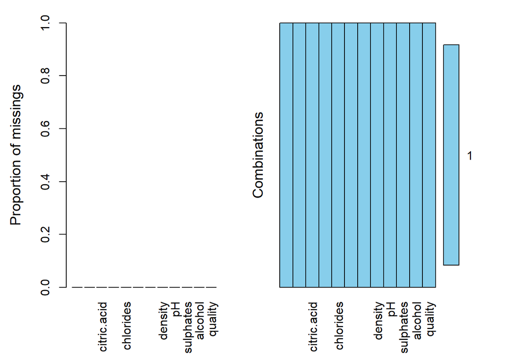

```
##
##  Missings per variable:
##              Variable Count
##         fixed.acidity     0
##      volatile.acidity     0
##           citric.acid     0
##        residual.sugar     0
##             chlorides     0
##   free.sulfur.dioxide     0
##  total.sulfur.dioxide     0
##               density     0
##                    pH     0
##             sulphates     0
##               alcohol     0
##               quality     0
##
##  Missings in combinations of variables:
##             Combinations Count Percent
##  0:0:0:0:0:0:0:0:0:0:0:0  4898     100
```

```r
summary(aggr(Tabla, numbers = TRUE))
```

No tenemos registros vacios en nuestra tabla.

¿Nuestra tabla contiene algun valor nulo?

```r
sapply(Tabla, function(x) all(!is.na(x)))
```

```
##        fixed.acidity     volatile.acidity          citric.acid
##                 TRUE                 TRUE                 TRUE
##       residual.sugar            chlorides  free.sulfur.dioxide
##                 TRUE                 TRUE                 TRUE
## total.sulfur.dioxide              density                   pH
##                 TRUE                 TRUE                 TRUE
##            sulphates              alcohol              quality
##                 TRUE                 TRUE                 TRUE
```

La formula esta orientada a saber si NO hay valores nulos. Todas las variables han aparecido con el booleano TRUE, por lo que ninguna de nuestras variables contine algun valor nulo.

¿Hay algun valor o valores que puedan afectar el analisis de esta tabla?

Realizamos un breve analisis de las variables de nuestra tabla:

```r
summary(Tabla)
```

```
##  fixed.acidity    volatile.acidity  citric.acid     residual.sugar
##  Min.   : 3.800   Min.   :0.0800   Min.   :0.0000   Min.   : 0.600
##  1st Qu.: 6.300   1st Qu.:0.2100   1st Qu.:0.2700   1st Qu.: 1.700
##  Median : 6.800   Median :0.2600   Median :0.3200   Median : 5.200
##  Mean   : 6.855   Mean   :0.2782   Mean   :0.3342   Mean   : 6.391
##  3rd Qu.: 7.300   3rd Qu.:0.3200   3rd Qu.:0.3900   3rd Qu.: 9.900
##  Max.   :14.200   Max.   :1.1000   Max.   :1.6600   Max.   :65.800
##    chlorides       free.sulfur.dioxide total.sulfur.dioxide    density
##  Min.   :0.00900   Min.   :  2.00      Min.   :  9.0        Min.   :0.9871
##  1st Qu.:0.03600   1st Qu.: 23.00      1st Qu.:108.0        1st Qu.:0.9917
##  Median :0.04300   Median : 34.00      Median :134.0        Median :0.9937
##  Mean   :0.04577   Mean   : 35.31      Mean   :138.4        Mean   :0.9940
##  3rd Qu.:0.05000   3rd Qu.: 46.00      3rd Qu.:167.0        3rd Qu.:0.9961
##  Max.   :0.34600   Max.   :289.00      Max.   :440.0        Max.   :1.0390
##        pH          sulphates         alcohol         quality
##  Min.   :2.720   Min.   :0.2200   Min.   : 8.00   Min.   :3.000
##  1st Qu.:3.090   1st Qu.:0.4100   1st Qu.: 9.50   1st Qu.:5.000
##  Median :3.180   Median :0.4700   Median :10.40   Median :6.000
##  Mean   :3.188   Mean   :0.4898   Mean   :10.51   Mean   :5.878
##  3rd Qu.:3.280   3rd Qu.:0.5500   3rd Qu.:11.40   3rd Qu.:6.000
##  Max.   :3.820   Max.   :1.0800   Max.   :14.20   Max.   :9.000
```

¿Tenemos valores duplicados en nuestra tabla?

Al no tener ninguna variable que funcione como identificador del vino, debemos considerar que los vinos blancos en nuestra tabla que tengan todas las variables identicas a otro vino, sera un valor duplicado.

```r
nrow(Tabla[duplicated(Tabla), ])
```

```
## [1] 937
```

```r
nrow(Tabla[!duplicated(Tabla), ])
```

```
## [1] 3961
```

De una tabla formada por 4898 posibles vinos blancos, hemos detectado que 937 son duplicados y 3961 son los vinos blancos que debemos tener una vez eliminemos los duplicados. Eliminamos los vinos duplicados:

```r
Tabla<-Tabla[!duplicated(Tabla), ]
```

Realizamos una ultima comprobacion para verificar que con la tabla final no hay valores duplicados y asi poder empezar a trabajar con ella:

```r
nrow(Tabla[duplicated(Tabla), ])
```

```
## [1] 0
```

Nuestra tabla final contiene 3961 vinos blancos sin duplicados, sin valores vacios y sin valores nulos.

2-

Modificamos la variable quality, inicialmente en formato entero y lo convertimos en formato factor con valores enteros entre el 3 y el 9:

```r
Tabla$quality <- factor(Tabla$quality, labels=c(3,4,5,6,7,8,9))
```

La variable quality ahora es un factor compuesto por 7 categorias (levels):

```r
class(Tabla$quality)
```

```
## [1] "factor"
```

```r
levels(Tabla$quality)
```

```
## [1] "3" "4" "5" "6" "7" "8" "9"
```

La tabla de los vinos dividido por su calidad:

```r
summary(Tabla$quality)
```

```
##    3    4    5    6    7    8    9
##   20  153 1175 1788  689  131    5
```

Los valores estan concentrados en el level 6 de calidad, con una distribucion muy parecida a una Normal.

Los % de vinos divididos por la calidad:

```r
round(prop.table(table(Tabla$quality))*100, digits = 2)
```

```
##
##     3     4     5     6     7     8     9
##  0.50  3.86 29.66 45.14 17.39  3.31  0.13
```

Con un valor de calidad = 6 hay un 45% de los vinos de nuestra tabla, conforme la calidad sube o baja, el % de vinos va reduciendose considerablemente. Hay pocos vinos con una calidad = 4 o con una calidad = 8, pero muchos menos con la minima calidad posible y aun menos con la maxima calidad posible.

3-

Crear una nueva variable indicando baja calidad en caso de tener quality entre 3 y 6, indicar alta calidad en caso de que la etiqueta quality sea > 6 (hasta 9).

```r
Tabla <- Tabla %>%
  mutate(categoria_calidad = case_when(quality %in% c("3", "4", "5", "6") ~ 'Baja Calidad',quality %in% c("7", "8", "9") ~ 'Alta Calidad'))
```

Transformamos la nueva variable categoria_calidad en factor binario:

```r
Tabla$categoria_calidad <- factor(Tabla$categoria_calidad, labels=c('Alta Calidad','Baja Calidad' ))
```

Comprobamos que la variable categoria calidad, sea un factor, binario y que todos los vinos esten clasificados entre Alta y baja calidad segun la quality:

```r
class(Tabla$categoria_calidad)
```

```
## [1] "factor"
```

```r
levels(Tabla$categoria_calidad)
```

```
## [1] "Alta Calidad" "Baja Calidad"
```

```r
sum(table(Tabla$categoria_calidad)) == nrow(Tabla)
```

```
## [1] TRUE
```

Nuestra nueva variable, es un factor binario que categoriza toda nuestra tabla.

4-

Determinamos la cantidad de vinos con la etiqueta alta calidad y los vinos con baja calidad:

```r
summary(Tabla$categoria_calidad)
```

```
## Alta Calidad Baja Calidad
##          825         3136
```

Hay muchos mas vinos etiquetados como baja calidad comparado con los vinos de alta calidad.

Usamos la funcion prop.talbe de la tabla categoria calidad, para multiplicarla por 100 para sacar el % de vinos con alta y baja calidad:

```r
round(prop.table(table(Tabla$categoria_calidad))*100, digits = 2)
```

```
##
## Alta Calidad Baja Calidad
##        20.83        79.17
```

Los 825 vinos de alta calidad, dentro de la tabla con un total de 3961 observaciones, equivale a un 20.83% de vinos.El 79.17 % restante son vinos etiquetados como baja calidad, traducido a observaciones, son un total de 3136 de 3961 observaciones.

5-

Dividimos la tabla principal en dos nuevas tablas aleatoriamente, una con el 70% y la otra con el 30%:

```r
sample_size <- floor(0.7*nrow(Tabla))
set.seed(1234)
Train_index <- sample(seq_len(nrow(Tabla)), size=sample_size )
```

- Tabla Training, con el 70% de nuestra tabla y comprobamos que no contenga duplicados:

```r
Train <- Tabla[Train_index,]
nrow(Train[duplicated(Train), ])
```

```
## [1] 0
```

- Tabla Test, con el 30% de nuestra tabla y comprobamos que no contenga duplicados:

```r
Test <- Tabla[-Train_index,]
nrow(Test[duplicated(Test), ])
```

```
## [1] 0
```

Ahora tenemos las 3961 observaciones divididas en una tabla de 2772 nombrada Train y las 1189 observaciones restantes en una tabla nombrada Test

6-

Revisamos las correlaciones entre todas las variables numericas de nuestra Tabla Train:

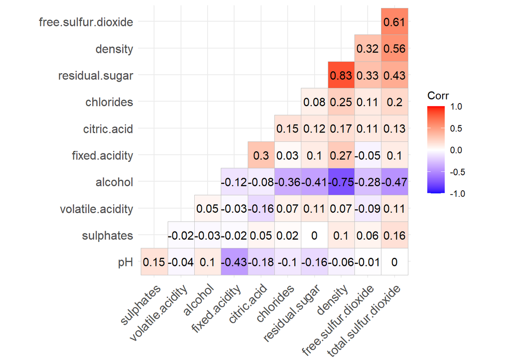

```r
ggcorrplot(cor(Train[ , c(1,2,3,4,5,6,7,8,9,10,11)], use="complete.obs"), hc.order=TRUE, type="lower", lab=TRUE)
```

Hay algunas variables que usaremos en el primer model altamente correlacionadas, entre ellas destacamos la alta correlacion entre el azucar residual y la densidad del vino, dicha correlacion es positiva y de 0.83. La correlacion entre el alcohol y la densidad tambien es alta, de -0.75, pero esta vez la correlacion es negativa, como mas densidad tenga el vino, menos alcohol.

Alguna de estas variables con alta correlacion entre si, podrian afectar la precision de nuestro modelo predictivo.

Determinamos que en la tabla train la categoria Alta Calidad es 1 y la categoria Baja Calidad es 0, asi nuestro modelo predictivo intentara ajustar la probabilidad de que un vino blanco sea categorizado como Alta Calidad.

```r
Train$categoria_calidad<-ifelse(Train$categoria_calidad=="Alta Calidad", 1, 0)
```

Modelo de regresion logistica multiple para determinar si el vino es Alta Calidad (1) o Mala Calidad (0) contando con todas las varaibles descriptivas de nuestra tabla:

```r
options(scipen = 100)
modelo<-glm(categoria_calidad~fixed.acidity + volatile.acidity + citric.acid+ residual.sugar + chlorides + free.sulfur.dioxide + total.sulfur.dioxide + density + pH + sulphates + alcohol, data=Train, family=binomial)
summary(modelo)
```

```
##
## Call:
## glm(formula = categoria_calidad ~ fixed.acidity + volatile.acidity +
##     citric.acid + residual.sugar + chlorides + free.sulfur.dioxide +
##     total.sulfur.dioxide + density + pH + sulphates + alcohol,
##     family = binomial, data = Train)
##
## Deviance Residuals:
##     Min       1Q   Median       3Q      Max
## -2.0377  -0.6408  -0.3570  -0.1502   2.9298
##
## Coefficients:
##                         Estimate  Std. Error z value          Pr(>|z|)
## (Intercept)           678.759511  130.931321   5.184 0.000000217074231 ***
## fixed.acidity           0.625674    0.125170   4.999 0.000000577529882 ***
## volatile.acidity       -3.220133    0.646435  -4.981 0.000000631340978 ***
## citric.acid            -0.410431    0.525002  -0.782          0.434349
## residual.sugar          0.293029    0.049281   5.946 0.000000002745519 ***
## chlorides             -15.644666    5.232677  -2.990          0.002792 **
## free.sulfur.dioxide     0.015462    0.004467   3.462          0.000536 ***
## total.sulfur.dioxide   -0.003054    0.002112  -1.446          0.148193
## density              -705.702480  132.749928  -5.316 0.000000106056210 ***
## pH                      4.274733    0.593500   7.203 0.000000000000591 ***
## sulphates               2.097571    0.473670   4.428 0.000009496322041 ***
## alcohol                 0.154557    0.158639   0.974          0.329922
## ---
## Signif. codes:  0 '***' 0.001 '**' 0.01 '*' 0.05 '.' 0.1 ' ' 1
##
## (Dispersion parameter for binomial family taken to be 1)
##
##     Null deviance: 2859.6  on 2771  degrees of freedom
## Residual deviance: 2204.6  on 2760  degrees of freedom
## AIC: 2228.6
##
## Number of Fisher Scoring iterations: 6
```

El coeficiente estimado para el intercepto es el valor esperado del logaritmo de odds ((e<sup>estimate)/(1+e</sup>estimate)) de que un vino blanco sea categorizado como “Alta Calidad” teniendo en cuenta que el resto de variables son 0, en este caso, el logaritmo de odds del intercepto es igual a 1 (Alta calidad). El p-value del intercepto es muy bajo, casi nulo, por lo que el valor estimado del intercepto es significativo en nuestro modelo.

La variable citric acid con un p-value = 0.43 > 0.05, es decir, esta variable no es significativa en nuestro modelo, es la primera variable que descartaremos para intentar mejorar el modelo actual.

La variable alcohol tiene un p-value superior a 0.05, por lo que en este modelo consideramos que no es significativo.

La variable total.sulfur.dioxide tambien tiene un p-value superior a 0.05, es decir, en nuestro modelo predictivo no aporta valor. El resto de variables si que parecen aportar valor para predecir si el vino es bueno o malo al tener p-values inferiores a 0.05.

Los errores estandar de las variables son muy bajos en general, con las excepciones del intercepto y la densidad, aunque son los valores que cuentan con estimadores mucho mas elevados ( ya sea + o - ) que el resto.

El z-value es muy parecido al t-value, pero el caso del valor z procede de distribucion z y es utilizado para los modelos logisticos. Tal y como podemos ver en el summary del modelo, como mayor es el valor z, mayor es la evidencia en frente la hypotesis nula. En caso de que el z-value sea cercano a 0, mas probable que la variable en cuestion no sea significativa. La variable con el z-value mas cercano a 0, es la variable que segun el p-value, es menos significativa para predecir la calidad del vino.

Creamos los intervalos al 95% de confianza basados en el error estandar con la foruma confint.default:

```r
confint.default(modelo)
```

```
##                               2.5 %         97.5 %
## (Intercept)           422.138837960  935.380184441
## fixed.acidity           0.380344742    0.871003071
## volatile.acidity       -4.487122125   -1.953144768
## citric.acid            -1.439415044    0.618553117
## residual.sugar          0.196440896    0.389617416
## chlorides             -25.900525385   -5.388807589
## free.sulfur.dioxide     0.006708246    0.024216622
## total.sulfur.dioxide   -0.007193286    0.001085613
## density              -965.887558346 -445.517400859
## pH                      3.111494551    5.437971344
## sulphates               1.169194453    3.025948388
## alcohol                -0.156369187    0.465483821
```

Con estos intervalos de confianza, podemos plantear si hay alguna variable que podamos descartar desde otro punto de vista. Con la hipotesis nula de que el estimador de la variable = 0, a un 95% de confianza, con el modelo 1 podriamos descartar las variables citric acid, alcohol y total sulfur dioxide, al contener el valor 0 en el intervalo, no rechazamos las hipotesis para estas tres variables, es decir, con el modelo actual, estas variables no tienen efecto en el pronostico de la calidad del vino. Hemos llegado a una conclusion muy parecida a la anterior usando los p-value.

7- Realizamos un proceso step para determinar el mejor modelo:

```r
modelo2<-glm(categoria_calidad~fixed.acidity + volatile.acidity + citric.acid+ residual.sugar + chlorides + free.sulfur.dioxide + total.sulfur.dioxide + density + pH + sulphates + alcohol, data=Train, family=binomial) %>% stepAIC(trace = TRUE)
```

```
## Start:  AIC=2228.6
## categoria_calidad ~ fixed.acidity + volatile.acidity + citric.acid +
##     residual.sugar + chlorides + free.sulfur.dioxide + total.sulfur.dioxide +
##     density + pH + sulphates + alcohol
##
##                        Df Deviance    AIC
## - citric.acid           1   2205.2 2227.2
## - alcohol               1   2205.6 2227.6
## <none>                      2204.6 2228.6
## - total.sulfur.dioxide  1   2206.7 2228.7
## - chlorides             1   2215.0 2237.0
## - free.sulfur.dioxide   1   2216.6 2238.6
## - sulphates             1   2224.3 2246.3
## - fixed.acidity         1   2230.6 2252.6
## - volatile.acidity      1   2231.4 2253.4
## - density               1   2236.0 2258.0
## - residual.sugar        1   2243.6 2265.6
## - pH                    1   2259.7 2281.7
##
## Step:  AIC=2227.22
## categoria_calidad ~ fixed.acidity + volatile.acidity + residual.sugar +
##     chlorides + free.sulfur.dioxide + total.sulfur.dioxide +
##     density + pH + sulphates + alcohol
##
##                        Df Deviance    AIC
## - alcohol               1   2206.0 2226.0
## <none>                      2205.2 2227.2
## - total.sulfur.dioxide  1   2207.5 2227.5
## - chlorides             1   2215.8 2235.8
## - free.sulfur.dioxide   1   2217.2 2237.2
## - sulphates             1   2224.9 2244.9
## - fixed.acidity         1   2230.6 2250.6
## - volatile.acidity      1   2231.6 2251.6
## - density               1   2237.3 2257.3
## - residual.sugar        1   2244.5 2264.5
## - pH                    1   2260.6 2280.6
##
## Step:  AIC=2226.02
## categoria_calidad ~ fixed.acidity + volatile.acidity + residual.sugar +
##     chlorides + free.sulfur.dioxide + total.sulfur.dioxide +
```

[output cut: 13 more lines]

```
##
## Step:  AIC=2225.87
## categoria_calidad ~ fixed.acidity + volatile.acidity + residual.sugar +
##     chlorides + free.sulfur.dioxide + density + pH + sulphates
##
##                       Df Deviance    AIC
## <none>                     2207.9 2225.9
## - free.sulfur.dioxide  1   2218.0 2234.0
## - chlorides            1   2218.5 2234.5
## - sulphates            1   2232.4 2248.4
## - volatile.acidity     1   2237.9 2253.9
## - fixed.acidity        1   2274.5 2290.5
## - pH                   1   2317.8 2333.8
## - residual.sugar       1   2390.7 2406.7
## - density              1   2559.9 2575.9
```

```r
summary(modelo2)
```

```
##
## Call:
## glm(formula = categoria_calidad ~ fixed.acidity + volatile.acidity +
##     residual.sugar + chlorides + free.sulfur.dioxide + density +
##     pH + sulphates, family = binomial, data = Train)
##
## Deviance Residuals:
##     Min       1Q   Median       3Q      Max
## -2.0219  -0.6415  -0.3539  -0.1515   2.8941
##
## Coefficients:
##                        Estimate  Std. Error z value             Pr(>|z|)
## (Intercept)          814.493591   47.704710  17.074 < 0.0000000000000002 ***
## fixed.acidity          0.695347    0.086856   8.006  0.00000000000000119 ***
## volatile.acidity      -3.202063    0.607910  -5.267  0.00000013842525721 ***
## residual.sugar         0.336334    0.026152  12.861 < 0.0000000000000002 ***
## chlorides            -15.736855    5.228557  -3.010              0.00261 **
## free.sulfur.dioxide    0.011400    0.003567   3.196              0.00139 **
## density             -842.959951   49.272725 -17.108 < 0.0000000000000002 ***
## pH                     4.621802    0.454044  10.179 < 0.0000000000000002 ***
## sulphates              2.211002    0.446598   4.951  0.00000073920812425 ***
## ---
## Signif. codes:  0 '***' 0.001 '**' 0.01 '*' 0.05 '.' 0.1 ' ' 1
##
## (Dispersion parameter for binomial family taken to be 1)
##
##     Null deviance: 2859.6  on 2771  degrees of freedom
## Residual deviance: 2207.9  on 2763  degrees of freedom
## AIC: 2225.9
##
## Number of Fisher Scoring iterations: 6
```

Nuestro modelo final es el siguiente:

```r
modelo2<-glm(categoria_calidad~fixed.acidity + volatile.acidity + residual.sugar + chlorides + free.sulfur.dioxide + density + pH + sulphates, data=Train, family=binomial) %>% stepAIC(trace = FALSE)
summary(modelo2)
```

```
##
## Call:
## glm(formula = categoria_calidad ~ fixed.acidity + volatile.acidity +
##     residual.sugar + chlorides + free.sulfur.dioxide + density +
##     pH + sulphates, family = binomial, data = Train)
##
## Deviance Residuals:
##     Min       1Q   Median       3Q      Max
## -2.0219  -0.6415  -0.3539  -0.1515   2.8941
##
## Coefficients:
##                        Estimate  Std. Error z value             Pr(>|z|)
## (Intercept)          814.493591   47.704710  17.074 < 0.0000000000000002 ***
## fixed.acidity          0.695347    0.086856   8.006  0.00000000000000119 ***
## volatile.acidity      -3.202063    0.607910  -5.267  0.00000013842525721 ***
## residual.sugar         0.336334    0.026152  12.861 < 0.0000000000000002 ***
## chlorides            -15.736855    5.228557  -3.010              0.00261 **
## free.sulfur.dioxide    0.011400    0.003567   3.196              0.00139 **
## density             -842.959951   49.272725 -17.108 < 0.0000000000000002 ***
## pH                     4.621802    0.454044  10.179 < 0.0000000000000002 ***
## sulphates              2.211002    0.446598   4.951  0.00000073920812425 ***
## ---
## Signif. codes:  0 '***' 0.001 '**' 0.01 '*' 0.05 '.' 0.1 ' ' 1
##
## (Dispersion parameter for binomial family taken to be 1)
##
##     Null deviance: 2859.6  on 2771  degrees of freedom
## Residual deviance: 2207.9  on 2763  degrees of freedom
## AIC: 2225.9
##
## Number of Fisher Scoring iterations: 6
```

logit (Probabilidad de vino alta calidad) = +814.49 + 0.69* Fixed_acidity - 3.20* volatile_acidity + 0.33* residual_sugar - 15.73* chlorides + 0.01* fre_sulfur - 842.95* density + 4.62* ph + 2.21 * sulphates

Para determinar la interpretacion de los coeficientes estimados para cada variable, debemos tener claro que los coeficientes indican el incremento de la probabilidad de que el vino blanco sea de alta calidad en escala logaritmica.

Los coeficientes positivos de nuestro modelo indican que como mas grandes sean las variables, mas augmentara el logaritmo del coeciente de probabilidad, es decir, como mas fixed acidity, residual sugar, free sulfur, ph y sulphates tenga nuestro vino, dejando el resto de variables estaticas, mas probabilidades de que el vino sea bueno.

En caso de que los coeficientes sean negativos, indica exactamente lo contrario, un vino blanco como mas volatile acidity, chlorides y densidad tengan, menores seran las probabilidades de que el vino sea bueno.

Segun el p-value de todas las variables, muestran que son sifnificativas para nuestro modelo predictivo.

Revisamos los intervalos de confianza:

```r
confint.default(modelo2)
```

```
##                              2.5 %        97.5 %
## (Intercept)          720.994078317  907.99310405
## fixed.acidity          0.525113115    0.86558176
## volatile.acidity      -4.393545231   -2.01057999
## residual.sugar         0.285077402    0.38759149
## chlorides            -25.984639456   -5.48907132
## free.sulfur.dioxide    0.004409499    0.01839139
## density             -939.532718187 -746.38718395
## pH                     3.731891551    5.51171163
## sulphates              1.335686334    3.08631676
```

No hay ninguna variable que contenga el valor 0 en su intervalo, por lo que determinamos que rechazamos al 95% de confianza de que nuestro modelo contenga alguna variable que NO aporte en la prediccion. Todas las variables tienen efecto en el pronostico de la calidad del vino.

¿Es nuestro modelo significativo para explicar la calidad del vino blanco?

Debemos determinar si nuestro modelo es mejor explicando la calidad del vino, respecto al modelo nulo:

Calculamos la diferencia de los residuos entre el modelo2 y el modelo nulo(sin predictores)

```r
dif_residuos <- modelo2$null.deviance - modelo2$deviance
dif_residuos
```

```
## [1] 651.7594
```

Calculamos la diferencia de los grados de libertad entre el modelo2 y el modelo nulo(sin predictores)

```r
df <- modelo2$df.null - modelo2$df.residual
df
```

```
## [1] 8
```

Con la formula anova, usando el test chisq podemos determinar la diferencia que aporta cada variable en los grados de libertad, en la diferencia de los residuos y la Pr(>Chi)

```r
anova(modelo2, test = "Chisq")
```

```
## Analysis of Deviance Table
##
## Model: binomial, link: logit
##
## Response: categoria_calidad
##
## Terms added sequentially (first to last)
##
##
##                     Df Deviance Resid. Df Resid. Dev              Pr(>Chi)
## NULL                                 2771     2859.6
## fixed.acidity        1   27.212      2770     2832.4      0.00000018227977 ***
## volatile.acidity     1   13.044      2769     2819.4             0.0003043 ***
## residual.sugar       1   48.267      2768     2771.1      0.00000000000372 ***
## chlorides            1  187.266      2767     2583.8 < 0.00000000000000022 ***
## free.sulfur.dioxide  1    2.810      2766     2581.0             0.0936951 .
## density              1  233.434      2765     2347.6 < 0.00000000000000022 ***
## pH                   1  115.148      2764     2232.4 < 0.00000000000000022 ***
## sulphates            1   24.579      2763     2207.9      0.00000071329811 ***
## ---
## Signif. codes:  0 '***' 0.001 '**' 0.01 '*' 0.05 '.' 0.1 ' ' 1
```

Las variables que aportan mas en reducir la diferencia de los residuos ( diferencia entre prediccion y realidad ) son los chlorides, la densidad y el PH. Cada variable reduce en 1 el grado de libertad, es por eso, que el total de grado de libertad del modelo 2 con 8 variables predictoras, tiene una diferencia de 8 entre los grados de libertad del modelo 2 vs el modelo nulo. Como menor sea la desviance que aporte cada variable, es decir, como mas cerca de 1, eso indicaria que esa variable estaria quitando 1 grado de libertad y aportaria poco en nuestro modelo, obteniendo un pr(>Chi) superior a 0.05, indicando que la variable no aporta en nuestro modelo.

Actualmente en el modelo 2 la variable que aporta menos diferencia entre prediccion y realidad es free sulfur dioxide.

El modelo2 reduce en 651.75 la diferencia entre prediccion y realidad comparado con un modelo sin predictores, es decir, nuestro modelo es significativo al predecir la calidad del vino.

Usamos la funcion lrm, para generar el mismo modelo2, pero con esta funcion, obtenemos mas indicadores de ajuste de nuestro modelo:

```r
modelo2<-lrm(categoria_calidad~fixed.acidity + volatile.acidity + residual.sugar
            + density + pH + sulphates +  chlorides + free.sulfur.dioxide , data=Train)
modelo2
```

```
## Logistic Regression Model
##
##  lrm(formula = categoria_calidad ~ fixed.acidity + volatile.acidity +
##      residual.sugar + density + pH + sulphates + chlorides + free.sulfur.dioxide,
##      data = Train)
##
##                         Model Likelihood    Discrimination    Rank Discrim.
##                               Ratio Test           Indexes          Indexes
##  Obs          2772    LR chi2     651.76    R2       0.326    C       0.820
##   0           2186    d.f.             8    g        1.729    Dxy     0.640
##   1            586    Pr(> chi2) <0.0001    gr       5.637    gamma   0.640
##  max |deriv| 5e-11                          gp       0.213    tau-a   0.213
##                                             Brier    0.127
##
##                      Coef      S.E.    Wald Z Pr(>|Z|)
##  Intercept            814.4936 47.7047  17.07 <0.0001
##  fixed.acidity          0.6953  0.0869   8.01 <0.0001
##  volatile.acidity      -3.2021  0.6079  -5.27 <0.0001
##  residual.sugar         0.3363  0.0262  12.86 <0.0001
##  density             -842.9600 49.2727 -17.11 <0.0001
##  pH                     4.6218  0.4540  10.18 <0.0001
##  sulphates              2.2110  0.4466   4.95 <0.0001
##  chlorides            -15.7369  5.2286  -3.01 0.0026
##  free.sulfur.dioxide    0.0114  0.0036   3.20 0.0014
##
```

La tabla inferior es exactamente la misma que hemos comentado antes.

En la parte superior primero nos indica, que de un total de 2772 observaciones, tenemos 2186 categorizadas como 0 ( Baja calidad ) y 586 como 1 ( Alta calidad ).

El model likelihood es un estimador por maxima verosimilitud, nos ayuda a estimar los parametros del modelo y realizar ajustes. Es utilizado para determinar la diferencia entre los residuos generados por el modelo vs el modelo nulo (sin predictores), explicado anteriormente.

El R2 que aparece en la tabla de discrimination Index, no es el mismo R2 utilizado con los modelos de regresion lineal, este un PseudoR2 ( una forma de intentar saber como encaja nuestro modelo en terminos de bondad de ajuste.) Esta formula utiliza una de las muchas formas de aproximar este PseudoR2, en concreto, utiliza la Nagelkerke pseudoR^2 tambien conocida como CraggUhler R^2. El resultado del PseudoR2 = 0.326, normalmente es inferior al R2 de los modelos de regresion lineal.

Comparamos el modelo2 con el modelo 1 ( con todas las variables ):

```r
lrtest0 <- lrtest(modelo,modelo2 )
lrtest0
```

```
##
## Model 1: categoria_calidad ~ fixed.acidity + volatile.acidity + citric.acid +
##     residual.sugar + chlorides + free.sulfur.dioxide + total.sulfur.dioxide +
##     density + pH + sulphates + alcohol
## Model 2: categoria_calidad ~ fixed.acidity + volatile.acidity + residual.sugar +
##     density + pH + sulphates + chlorides + free.sulfur.dioxide
##
## L.R. Chisq       d.f.          P
##  3.2614122  3.0000000  0.3530496
```

Vemos que el modelo con las variables alcohol, citric acid y total sulfur dioxide, aportan 3 grados de libertad de mas con un p value muy superior a 0.05. Esto significa que quitando estas tres variables, el modelo es mas significativo. Podemos decir que el modelo2 es mejor que el modelo con todas las variables predictoras. El modelo2 tiene mejores datos utilizando el modelo likelihood.

El modelo mas significativo y con mayor bondad de ajuste es el siguiente:

```r
modelo2<-glm(categoria_calidad~ density + pH +chlorides+ fixed.acidity + residual.sugar+ volatile.acidity + free.sulfur.dioxide + sulphates, data=Train, family=binomial) %>% stepAIC(trace = FALSE)
```

El modelo 2 se ajusta mas comparado con el resto de modelos al predecir la probabilidad de que el vino sea de alta calidad o baja calidad.

Dibujamos la curva de regresion logistica con la formula ggPredict dejando estables los valores: fixed acidity, residual sugar, volatile acidity, free sulfur dioxide y sulphates.

```r
GRAFICA_REGRESION <- ggPredict(modelo2,se=TRUE,show.text = FALSE)
```

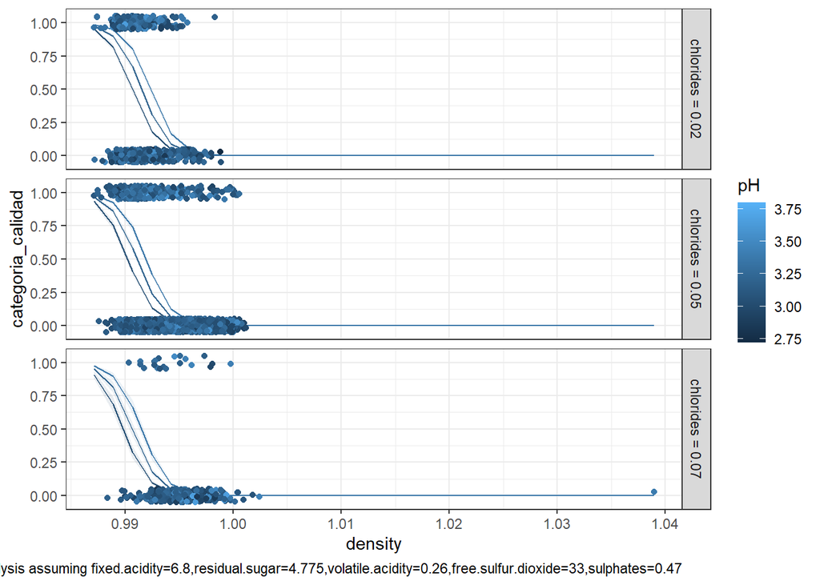

Con la grafica de la regresion logistica anterior, confirmamos lo comentado anteriormente: Los vinos con pocos chlorides, con poca densidad y con un ph alto tienen mas probabilidades de que nuestro modelo lo categorize como vino de alta calidad.

Con chlorides bajos podemos ver como la curva no baja tan rapido comparado con la tercera grafica, es decir, en caso de que un vino tenga muy pocos chlorides puede hacer que la densidad no afecte tanto a la probabilidad final, aunque es cierto, que cuando la densidad crece, hay muchas menos posibilidades de que el vino sea bueno segun el modelo. Un ph alto ayuda a que el resultado final sea que el vino resulte de alta calidad.

CONCLUSION

¿Como saber si nuestro modelo categorizara el vino como alta?

Para que el resultado sea una alta probabilidad de buena calidad:

1- Nos debemos fijar si los chlorides estan por debajo de 0.05, como mas cerca de 0.02 mejor.

2- La densidad debe estar mas cerca de 0.98 que de 1.

3- Un PH elevado, como mas cerca de 3.75 mejor.

4- La variable sulphates ayuda en caso de que el vino tenga una canidad superior a la media.

5- El resto de variables bastante cerca de la media, es decir, que tenga valores normales.

Si el vino blanco cumple los 5 requisitos anteriores, segun el modelo final, el vino tendra muchas probabilidades de que el vino sea bueno.

8-

Generamos las probabilidades asociadas usando el modelo2, redondeamos las predicciones y las multiplicamos por 100 en la tabla Test:

```r
Predicciones<-predict(modelo2, newdata=Test, type = "response")
Predicciones=round(Predicciones*100, digits=2)
```

Creamos una nueva variable que sea la Probabilidad de que el vino sea de Alta calidad:

```r
Test <- Test %>%
  mutate(Prob_Alta_Calidad = Predicciones)
```

Creamos una nueva variable categorica donde si la prob. es superior a 33.33% denominamos que el vino es de alta calidad ( segun nuestro modelo ) y si el vino tiene una prob. menor o igual a 33.33% denominamos que el vino es de baja calidad ( segun nuestro modelo)

```r
Test <- Test %>%
  mutate(Prediccion_Calidad = case_when(Prob_Alta_Calidad>33.33 ~ 'Alta Calidad',Prob_Alta_Calidad<=33.33 ~ 'Baja Calidad'))
```

9-

Creamos una tabla con las predicciones de nuestro modelo y las observaciones de la Tabla Test:

```r
Predicciones_vs_observaciones <- table(Test$categoria_calidad, Test$Prediccion_Calidad, dnn=c("observaciones", "Predicciones"))
Predicciones_vs_observaciones
```

```
##               Predicciones
## observaciones  Alta Calidad Baja Calidad
##   Alta Calidad          136          103
##   Baja Calidad          151          799
```

Tenemos un total de 136 vinos blancos que segun nuestro modelo son de alta calidad con una calidad real alta, pero tenemos 151 vinos blancos con la etiqueta de alta calidad que realmente no son de alta calidad.

Segun nuestro modelo, tenemos 103 vinos blancos de baja calidad pero que realmente son de alta calidad, finalmente tenemos 799 vinos blancos de baja calidad segun el modelo y que realmente son de baja calidad.

Creamos un mosaico donde el color azul significa acierto. En la parte superior se muestra el acierto de las observaciones de alta calidad y en la parte inferior los aciertos de la baja calidad del vino. El color rojo significa error, donde en la parte superior estan los vinos de Alta calidad que hemos fallado prediciendo que son de baja calidad y en la parte inferior son los vinos de baja calidad que hemos determinado de manera incorrecta que segun la prediccion eran de alta calidad.

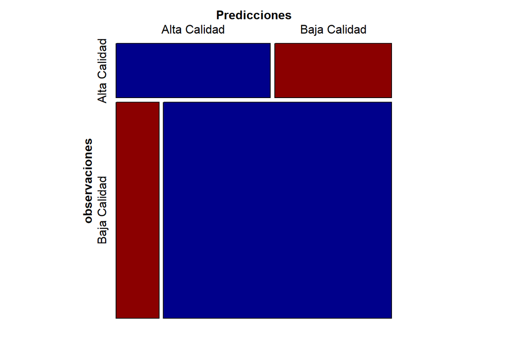

```r
mosaic(Predicciones_vs_observaciones, shade = T, colorize = T, split_vertical = F,
       gp = gpar(fill = matrix(c("blue4", "red4", "red4", "blue4"), 2, 2)))
```

Tal y como vemos representado en el anterior mosaico, la probabilidad de acertar un vino de Alta calidad es mas baja que el de un vino de Baja calidad.

Precision de nuestro modelo usando la tabla test:

Sumamos los aciertos, divido por el total de los vinos blancos de la tabla test

```r
acierto_total <- round((sum(Predicciones_vs_observaciones[1,1], Predicciones_vs_observaciones[2,2])/sum(Predicciones_vs_observaciones))*100, digits = 2)
acierto_total
```

```
## [1] 78.64
```

```r
error_total <- round((sum(Predicciones_vs_observaciones[1,2], Predicciones_vs_observaciones[2,1])/sum(Predicciones_vs_observaciones))*100, digits = 2)
error_total
```

```
## [1] 21.36
```

Nuestro modelo acierta en un 78.64% de las observaciones. El modelo es bueno al predecir si un vino blanca es de alta calidad o de baja al obtener un 21.36% de probabilidad de error.

Tenemos un total de:

Prediccion vinos blancos de alta calidad:

```r
acierto_alta_calidad <- round((Predicciones_vs_observaciones[1,1])/sum(Predicciones_vs_observaciones[1,1],Predicciones_vs_observaciones[2,1] )*100, digits = 2)
acierto_alta_calidad
```

```
## [1] 47.39
```

```r
error_alta_calidad <- round((Predicciones_vs_observaciones[2,1])/sum(Predicciones_vs_observaciones[1,1],Predicciones_vs_observaciones[2,1] )*100, digits = 2)
error_alta_calidad
```

```
## [1] 52.61
```

Nuestro modelo acierta en el 47.39% de los vinos blancos que determina que son de alta calidad. Bastante por debajo del % de aciertos globales.

El modelo falla con un 52.61% de los vinos blancos que de termina alta calidad, este 52.61% realmente son de baja calidad

Prediccion vinos blancos de baja calidad:

```r
acierto_baja_calidad <- round((Predicciones_vs_observaciones[2,2])/sum(Predicciones_vs_observaciones[1,2],Predicciones_vs_observaciones[2,2] )*100, digits = 2)
acierto_baja_calidad
```

```
## [1] 88.58
```

```r
error_baja_calidad <- round((Predicciones_vs_observaciones[1,2])/sum(Predicciones_vs_observaciones[1,2],Predicciones_vs_observaciones[2,2] )*100, digits = 2)
error_baja_calidad
```

```
## [1] 11.42
```

Nuestro modelo acierta en el 88.58% de los vinos blancos que cataloga como baja calidad. Bastante por encima del % de aciertos globales. Un 11.42% de los vinos que cataloga como baja calidad, realmente son de alta calidad.

Podemos concluir que nuestro modelo es bueno prediciendo los vinos de baja calidad, con un 88.58% de aciertos, es decir, que si nuestro modelo categoriza un vino blanco de mala calidad, es muy probable que sea cierto. En caso de que el modelo categorize un vino blanco de alta calidad, tiene un 47.39% de probabilidad de que acierte, alrededor del 50%. Nuestro modelo es mas efectivo prediciendo vinos de mala calidad que vinos de buena calidad. La mayoria de errores de nuestro modelo, son por predecir que un vino es de alta calidad pero realmente tiene un calidad igual o inferior a 6.

Para poder mejorar el modelo, necesitariamos una tabla con una proporcion de vinos del alta calidad y de baja calidad parecida. Todas las tablas que hemos usado durante el ejercicio, siempre han contenido una mayor cantidad de vinos de baja calidad, esto proporciona a razonar que al usar tantos vinos de baja calidad, nuestro modelo es mucho mejor prediciendo este tipo de vinos que los de alta calidad.